# Graphiques avec ggplot2

## Changer les échelles

## Avec les fonctions `scale_***`

Ces fonctions vont vous permettre de personnaliser l’échelle, en \(x\), en \(y\), mais pas seulement ! Ce concept est généraliser dans `ggplot2` à de nombreux paramètres esthétiques. Par exemple :

## A vous !

Complétez la commande suivante pour obtenir le graphe ci-contre.

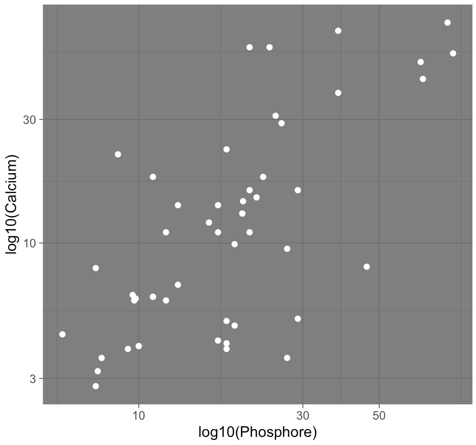

```r
ggplot(fruits,
       aes(Phosphore,
           Calcium)) +
  geom_point(*** = "white") +
  scale_***() +
  scale_***() +
  labs(x = "log10(Phosphore)",
       y = "log10(Calcium)") +
  theme_dark()
```

## Avec les fonctions `coord_***`

Pour modifier le système de coordonnées **après** avoir appliquer toutes les transformations spécifiées auparavant (par une fonction `scale_***` par exemple). Par exemple :

- `coord_fixed` pour fixer le ratio des unités de l’axe des \(y\) sur les unités de l’axe des \(x\),
- `coord_equal` quand ce ratio vaut 1,
- `coord_flip` pour échanger les axes,
- `coord_polar` pour passer d’un système de coordonnées cartésien à un système de coordonnées polaires

## Pour s’amuser !

Transformez les coordonnées du graphe suivant en coordonnées polaires (`coord_polar(theta = "y")`). Quel est le résultat ?

```r
ggplot(fruits, aes(x = 1, fill = groupe)) +
  geom_bar(width = 1) +
  theme_void()
```

## Avec les fonctions `*lim*`

Change le minimum et le maximum d’un axe. Attention, toutes les valeurs en dehors des nouveaux axes sont **éliminées** !

- `xlim`, `ylim` ou `lims` pour spécifier l’étendue,
- `expand_limits` pour *étendre* l’étendue à certaines valeurs.

## Créer des “facettes”

## La fonction `facet_wrap`

S’uilise pour diviser le graphe en panneaux selon les modalités d’une variable catégorielle.

Attention à la syntaxe : elle est basée sur l’utilisation du terme `vars`, qui permet d’accéder aux variables du jeu de données spécifié.

Par exemple, pour diviser le graphe `g` en plusieurs panneaux selon les modalités d’un facteur `fac`, on écrira

```
g + facet_wrap(facets = vars(fac))
```

On peut également utiliser une “formule” :

```
g + facet_wrap(~ fac)
```

## Exemple

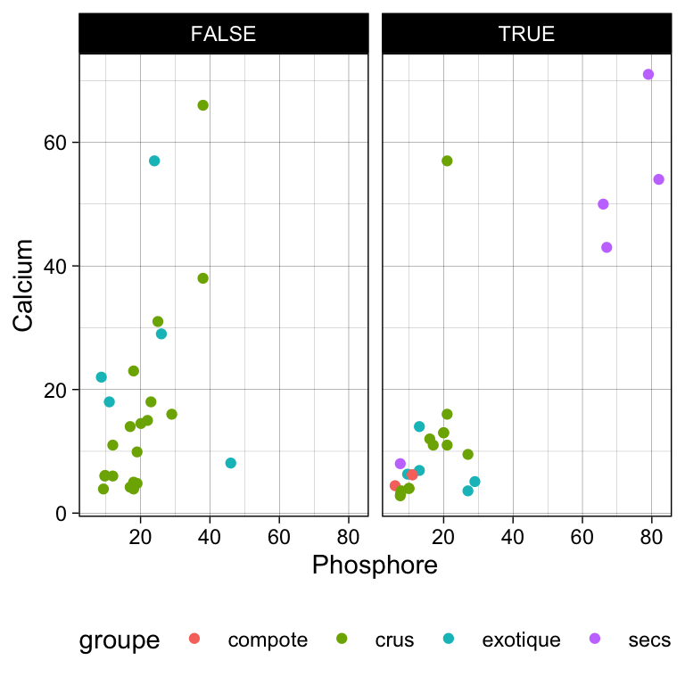

```r
ggplot(fruits,
       aes(x = Phosphore,
           y = Calcium,
           color = groupe)) +
  geom_point() +
  facet_wrap(vars(Sucres > 10)) +
  theme_bw() +
  theme(legend.position =
          "bottom")
```

## Avec la fonction `facet_grid`

S’utilise de la même façon que `facet_wrap`.

Par exemple, pour diviser le graphe `g` en plusieurs panneaux selon les modalités d’un facteur `factorow` pour les lignes et `factocol` pour les colonnes, on écrira

```
g + facet_grid(rows = vars(factorow), cols = vars(factocol))
```

On peut aussi utiliser une formule :

```
g + facet_grid(factorow ~ factocol)
```

CONSEIL : pour l’utilisation de facettes, faites attention à bien nommer les modalités de vos facteurs pour rendre le graphe plus clair.

## Sauvegarder un graphe

## Méthode conseillée : avec ggsave

Fonctionnement et exemple :

```
g <- ggplot(fruits, aes(groupe)) + geom_bar()
ggsave(filename = "mongraphe.png", plot = g)
```

L’extension donnée dans `filename` sera magiquement détectée pour sauvegarder le fichier au bon format !

## Conclusion

## En quelques mots

Nous avons vu un package de représentations graphiques très puissant ! `ggplot2` fonctionne sur la base d’un canevas, de paramètres esthétiques comme la position en \(x\), en \(y\), les couleurs, la forme etc. A partir de ces paramètres, on va tracer les graphes à l’aides de *géométries*, qui peuvent se superposer !

## Quelques remarques

1. `ggplot2` est très complet… et très complexe
2. Il faut prendre son temps, et savoir travailler avec ses petits jeux de données préférés bien connus et **très très très très propres** pour travailler sur son graphe,
3. Personnaliser un graphe prend du temps, il faut s’armer de patience…

## [N’oubliez pas la feuille de triche !](https://www.rstudio.com/wp-content/uploads/2015/03/ggplot2-cheatsheet.pdf)

[figure not shown]